# NOAA Storm Database Analysis

Rajesh Balasubramanian

September 25, 2015

# Synopsis

The purpose of the document is to perform data analysis on storm database from National Oceanic & Atmospheric Administration (NOAA), document the steps performed so that the analysis can be reprocible.

The goal of the analysis is to answer 2 questions.

- Across the United States, which types of events (as indicated in the EVTYPE variable) are most harmful with respect to population health?
- Across the United States, which types of events have the greatest economic consequences?

# Data Processing

Please note that [NOAA Storm Database](http://d396qusza40orc.cloudfront.net/repdata%2Fdata%2FStormData.csv.bz2) should available/to be downloaded to the current working directory.

```r
# Required packages
library(reshape2)
library(ggplot2)

# Option to limit the number of events, max number of events in a plot, to make it more readable
maxNumberOfEventsInPlot <- 5
```

## Loading of NOAA Storm Database

NOAA Storm database loaded through read.csv directly.

```r
dataFile <- "repdata_data_StormData.csv.bz2"

# If the dataFile doesn't exists in the current working directoy, download
if (!file.exists(dataFile)) {
        download.file("http://d396qusza40orc.cloudfront.net/repdata%2Fdata%2FStormData.csv.bz2", destfile = dataFile, method="curl")
}

# read.csv can handle CSV files with BZ2 compression!
stormData <- read.csv(dataFile)
```

## Pre-processing

Pre-processing of data for analysis - subsetting, calculated fields and transforms.

```r
# subset of the following is what we are interested for this analysis
# saving it back to stormData to free up memory
stormData <- subset(stormData, FATALITIES > 0 | INJURIES > 0 | PROPDMG > 0 | CROPDMG > 0)

# subset only the columns that we are interested for our data analysis to answer those 2 questions
stormData <- stormData[,c("EVTYPE", "FATALITIES", "INJURIES", "PROPDMG", "CROPDMG", "PROPDMGEXP", "CROPDMGEXP")]

# Property and Crops Damage codes/multiplier
damageMultiplier <- c('H' = 100, 'K' = 1000, 'M' = 1000000, 'B' = 1000000000 )

# There are many entries for PROPDMGEXP, we'll use H/h = 100, K/k = 1000, M/m = 1000000, B/b = 1000000000. For the rest of the codes, we'll ignore.
stormData$Propety_Damage <- damageMultiplier[toupper(stormData$PROPDMGEXP)] * stormData$PROPDMG

# There are many entries for CROPDMGEXP, we'll use K/k = 1000, M/m = 1000000, B/b = 1000000000. For the rest of the codes, we'll ignore.
stormData$Crop_Damage <- damageMultiplier[toupper(stormData$CROPDMGEXP)] * stormData$CROPDMG
```

## Preparing data for question #1

```r
# Prepare data for question # 1 - finding events that were most harmful to population
stormData.harmfulevents.melt <- melt(stormData, id.vars="EVTYPE", measure.vars=c("FATALITIES", "INJURIES"))

# Get rid of records with 0 injuries or 0 fatalities
stormData.harmfulevents.clean <- subset(stormData.harmfulevents.melt, value>0)

# Get the total (injuries + fatalities)
stormData.harmfulevents.total <- aggregate(stormData.harmfulevents.clean[c("value")], by=stormData.harmfulevents.clean[c("EVTYPE")], FUN=sum, na.rm=TRUE)

# Pick the top records for plots
stormData.harmfulevents.top <- subset(stormData.harmfulevents.clean, EVTYPE %in% stormData.harmfulevents.total[order(stormData.harmfulevents.total$value, decreasing=TRUE)[1:min(maxNumberOfEventsInPlot, length(stormData.harmfulevents.total$value))],]$EVTYPE)
```

## Preparing data for question #2

```r
# Prepare data for Property & Crop damages
stormData.melt <- melt(stormData, id.vars="EVTYPE", measure.vars=c("Propety_Damage", "Crop_Damage"))

# group-by event and damage type
stormData.summary <- aggregate(stormData.melt[c("value")], by=stormData.melt[c("EVTYPE", "variable")], FUN=sum, na.rm=TRUE)

# Get rid of damages with 0 value
stormData.summary.clean <- subset(stormData.summary, value>0)

# Get total damage from both Property and Crop damages
stormData.totaldamage <- aggregate(stormData.summary.clean[c("value")], by=stormData.summary.clean[c("EVTYPE")], FUN=sum, na.rm=TRUE)

# Get events with most damages for our plots
stormData.summary.top <- subset(stormData.summary.clean, EVTYPE %in% stormData.totaldamage[order(stormData.totaldamage$value, decreasing=TRUE)[1:min(maxNumberOfEventsInPlot, length(stormData.totaldamage$value))],]$EVTYPE)
```

# Results

### Across the United States, which types of events (as indicated in the EVTYPE variable) are most harmful with respect to population health?

From our analysis of the NOAA Storm database, the following events were most harmful with respect to population health across US.

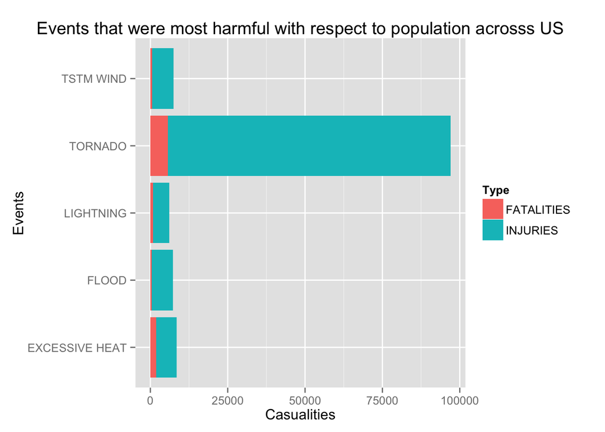

```r
ggplot(stormData.harmfulevents.top, aes(x = EVTYPE, y = value,fill=variable)) + geom_bar(stat='identity') + coord_flip() + labs(x="Events", y="Casualities", title="Events that were most harmful with respect to population acrosss US") + scale_fill_discrete(name="Type")
```

### Across the United States, which types of events have the greatest economic consequences?

From our analysis of the NOAA Storm database, the following events had the greatest economic consequences across US.

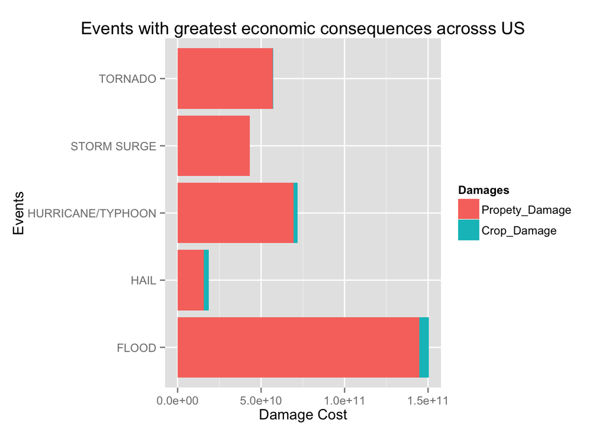

```r
ggplot(stormData.summary.top, aes(x = EVTYPE, y = value,fill=variable)) + geom_bar(stat='identity') + coord_flip() + labs(x="Events", y="Damage Cost", title="Events with greatest economic consequences acrosss US") + scale_fill_discrete(name="Damages")
```